# COMPUTO

*A new born academic journal promoting reproducibility*

2022 Toronto Workshop on Reproducibility

## Facts in Stats/ML academic publications

- Multiplication of academic journals and articles  
  *→ at the expense of quality / scientific accuracy?*
- Lack of valorisation of computer/algorithmic developments and case studies
- Saturation of existing solutions
- Rapid evolution of tools
  - Great API (`Rstudio`, `VScode`)
  - Scientific Publishing system (`quarto`, `Jupyter`)
  - Integration / dynamics (`git(hub)`, `Actions`)

**Computo’s Board Positionong**

**Need to renew the mode of publication of scientific knowledge and know-how**

## Existings solutions

### Standard academic journals

*Statistics and Computing, Computational Statistics and Data Analysis, Journal of Computational and Graphical Statistics, JMLR, JRSS-B, JASA, …*

**Limitations**

Fixed format (non-dynamic typically, PDF) limiting reproducibility

### Software journals

*R journal, Journal of Statistical Software, Journal of Open Source Software, JMLR Machine Learning Open Source Software, ROpen-Sci…*

**Limitations**

Congestion, language-centric, software documentation, not structured around a scientific question

## Computo in a nutshell

**Aims and Scope**

*Promote contributions in statistics and machine learning that provide insight into which models/methods are the most appropriate to a specific question.*

**Open and reproducible**

- reproducibility of numerical results is a necessary condition for publication
- all necessary data and code mus be available.
- reviews are open (with possible anonymous reviewers)

**Assessing reproductibility**

**At the submission stage!**

## Editorial Board

#### Chloé-Agathe Azencott

Machine Learning for therapeutic research  
Mines ParisTech, Inserm, Institut Curie

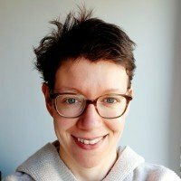

#### Pierre Neuvial

Statistics,  
CNRS, Institut de Mathématiques de Toulouse

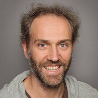

#### Julien Chiquet (Chief Editor)

Statistical learning for life science  
Université Paris-Saclay, AgroParisTech, INRAE

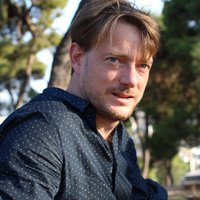

#### Nelle Varoquaux

Machine learning and causal inference for genomics  
CNRS, Université Grenoble Alpes

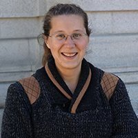

## Some inspiring initiatives

- Peer Community-In, Overlay journal (different spirit)
- https://rescience.github.io/ (“remake/redo” of existing works)
- https://distill.pub (technically complicated)

## About the Logo

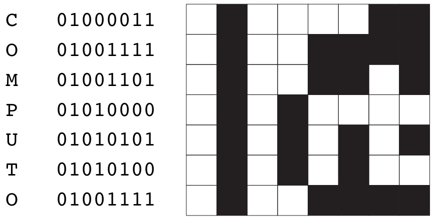

Computo’s logo has been designed by [Loïc Schwaller](https://loack.me/).

[figure not shown]